# Gov 50 Final Project

Lauren Cruickshank

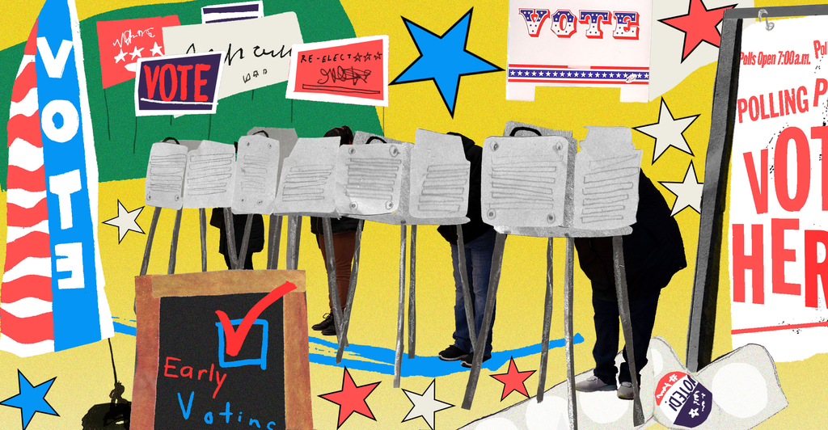

Click Image for 2024 Election Predictions

**Code Chart**

The data file for this study is `fpd.csv` and contains the following variables:

| **Name** | **Description** |
| --- | --- |
| `chamber` | whether the candidate is in the House or Senate |
| `candidate` | the names of candidate, party, and state |
| `selffunding` | how much money the candidate funded themselves |
| `collectedfunding` | how much money the candidate funded from outside sources |
| `overallfunding` | the overall money the candidate received in funding |
| `Percent Self-funded` | percent of funding the candidate funded from themselves |
| `result` | whether or not the candidate won or loss the election |
| `pervote` | share percentage of votes received by the candidate |

# Introduction

## **Background**

The 2024 presidential election cycle is currently approaching. As it is known, there is a host of factors that can effect ones campaign run and thus the results of the election. The U.S states government has formed very specific rules around the use of campaign funds and the way that they are used. Nonetheless, the main question this study hopes to examine is as follows: *Is there a Correlation Between the Amount of Campaign Funds a Candidate has and their Election Results?* If there is a correlation between these two factors, it would be important for candidates to understand before they run for an election. The data set represents the campaign funding and election results of House and Senate candidates from 2016 to 2020. The explanatory variable in this study is is the amount of funding that each candidate receives. The response variable or outcome is whether the candidate saw success in the election.

## **Hypotheses**

The Hypotheses of this Study are as follows:

1. As the **amount of available campaign funding increases** so will the **wins of the candidates increase**
2. As the **amount of available campaign funding increases** so will the **share percentage of votes received by candidates in the elections increase**

# Data Interest

```r
library(tidyverse)
library(dplyr)
library(readr)
library(gapminder)
library(infer)
library(moderndive)


cand_sp <- read_csv("fpd.csv")

cand_sp
```

[output not shown]

The sample used is comprised of data compiled by the OpenSecrets the “nation’s premier research group tracking money in U.S politics and its effect on elections and public policy. In this study, OpenSecret’s data on candidate spending and results from 2016 to 2020 were used. In order to include the percentage share by which the candidate won or loss, it had to be individually searched in the database of OpenSecret.

## Data Links:

[**OpenSecrets**](https://www.opensecrets.org/elections-overview/top-self-funders?cycle=2016)

The **independent variable** in this study is the *amount of money that each candidate has for campaign funding*. The **dependent variable** is the *share percentage of votes the candidates receive* and *the results that each candidate yielded from the election*.

If I observe that candidates with more campaign funding are having increased number of wins or increased share percentage of votes, my hypothesis would be supported. However, I observe that candidates with more campaign funding are having the same number of wins or losses or the same share percentage of votes, then my hypothesis has not been supported.

In order to identify a relationship between overall campaign funding, share percentage of votes from election, and candidates results from the election, this analysis is utilizing a cross-sectional design. Such a design can be seen as the data was collected at a single period of time.

The graph below represents the top twenty candidatures with the highest campaign funding from 2016 to 2020.

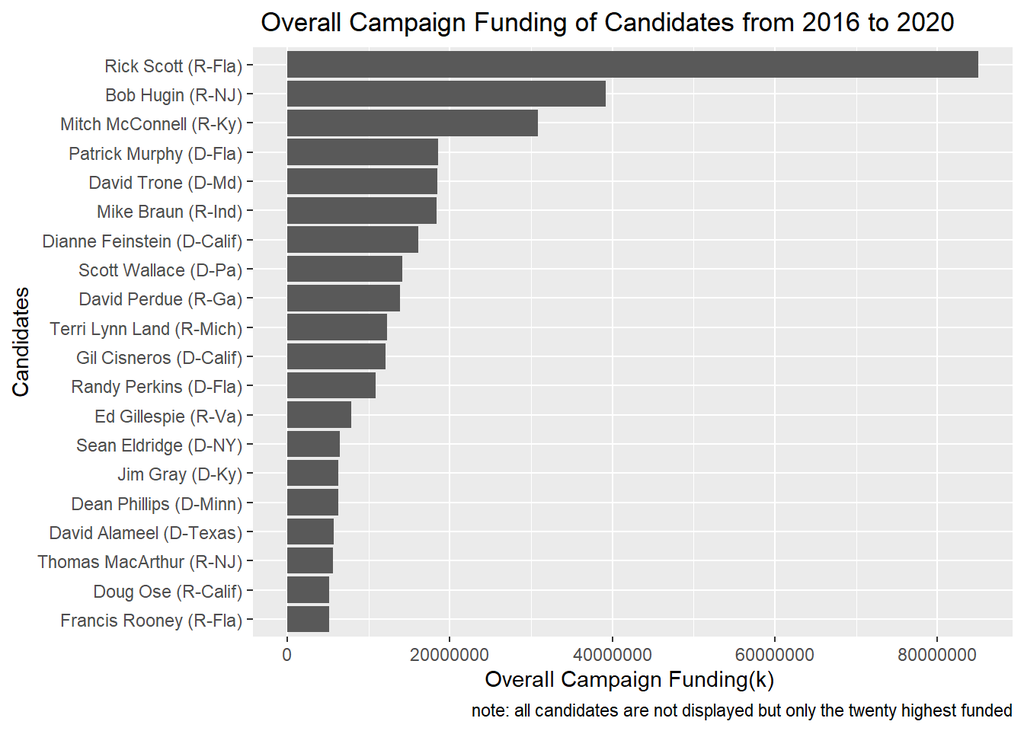

```r
# calculate the candidates with the top campaign funds
options(scipen = 999)


cand_sp|>
  slice_max(overallfunding, n = 20)|>
ggplot(
       mapping = aes(x = overallfunding, y = fct_reorder(Candidate, overallfunding))) +
  geom_col()+
  labs(x = "Overall Campaign Funding(k) ",
       y = "Candidates",
       title = " Overall Campaign Funding of Candidates from 2016 to 2020",
       caption = "note: all candidates are not displayed but only the twenty highest funded")
```

# Results

## **Linear Regression Between the Share of Votes and Overall Funding Broken Down by Loss and Win**

The following multivariate regression model demonstrates the relationship between the amount of money received for campaign funds, the share percentage of votes the candidate received from the election, and whether the candidate won or loss the overall election.

```r
#calculate the regression between campaign funding, share percentage of votes, and results of election
regr_1 <- lm(overallfunding ~ pervote + Result, data = cand_sp)

 r1 <- get_regression_table(regr_1)

knitr::kable(head(r1),digits = 2)
```

| term | estimate | std_error | statistic | p_value | lower_ci | upper_ci |
| --- | --- | --- | --- | --- | --- | --- |
| intercept | 2509749.46 | 5177210 | 0.48 | 0.63 | -7899729.1 | 12919228.0 |
| pervote | 87475.74 | 125817 | 0.70 | 0.49 | -165496.2 | 340447.7 |
| Result: Won | 6217351.12 | 4271917 | 1.46 | 0.15 | -2371913.3 | 14806615.5 |

### **Interpretation**

The intercept of $2,509,749.46 , is the estimated campaign funding when the share percentage of votes received by the candidate is zero and the candidate did not win the election. There is an expected increase of $87,475.74 in campaign funding for each unit increase in the share percentage points of votes received by the candidate , also assuming that the candidate winning status stays constant.

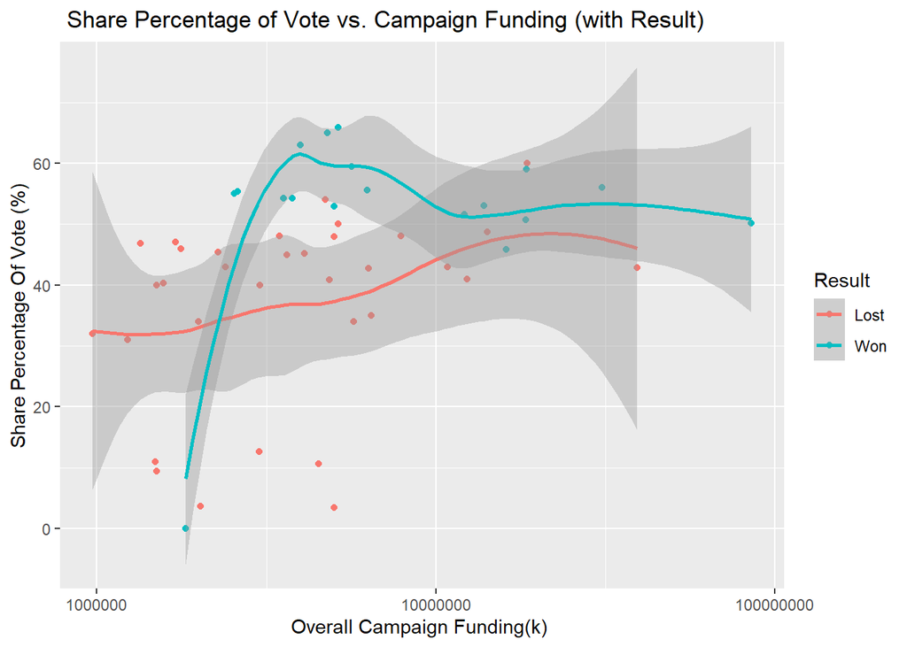

```r
# demonstrate the correlation between share percentage of votes and campaign funding separated by results

cand_sp|>
  ggplot(
    mapping = aes(
      x = overallfunding,
      y = pervote,
      color = Result))+
  geom_point()+
  geom_smooth()+
  scale_x_log10()+
   labs(x = "Overall Campaign Funding(k) ",
       y = "Share Percentage Of Vote (%)",
       title = " Share Percentage of Vote vs. Campaign Funding (with Result)")
```

```r
# calculating the difference in means of campaign funding for losing candidates vs winning candidates

ate <- cand_sp|>
  group_by(Result)|>
  summarize(overallfunding = mean(overallfunding))|>
  pivot_wider(names_from = Result, values_from = overallfunding)|>
  mutate(ATE = Won - Lost)|>
  select(ATE)
ate
```

```
## # A tibble: 1 × 1
##        ATE
##      <dbl>
## 1 7924110.
```

## **Linear Regression between the Share of Votes and Overall Funding**

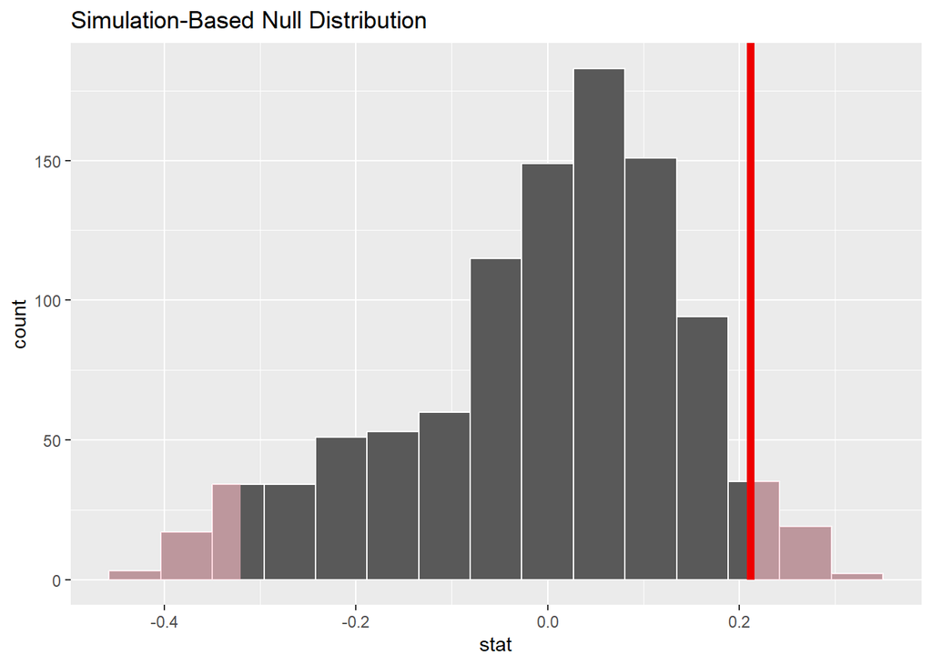

```r
#calculating null distribution

null_dist <- cand_sp |>
  specify(overallfunding ~ pervote) |>
  hypothesize(null = "independence") |>
  generate(reps = 1000, type = "permute") |>
  calculate(stat = "correlation")

correlation <- cand_sp |>
  specify(overallfunding ~ pervote) |>
  calculate(stat = "correlation")

null_dist |>
  visualize() +
  shade_p_value(correlation, direction = "both")
```

```r
get_p_value(null_dist, correlation, direction = "both")
```

[output not shown]

In this study, the null hypothesis suggest that there is no relationship between the amount of campaign funding a candidate received and the share percentage of votes they received in the election. With a significance level of ⍺ = 0.05, we would fail to reject the null hypothesis with a p-value of 0.072. Therefore, we conclude that there is not a statistically significant relationship between campaign funds and the share percentage of votes candidates receive in elections. Therefore, the relationship can not be interpreted causally.

The following regression displays the relationship between the the amount of funding a candidate received and the share percentage of votes they received during the election process.

```r
#caculating regression between campaign funding and share percentage of votes

regr_2 <- lm(overallfunding ~ pervote, data = cand_sp)

r2 <- get_regression_table(regr_2)

knitr::kable(head(r2),digits = 2)
```

| term | estimate | std_error | statistic | p_value | lower_ci | upper_ci |
| --- | --- | --- | --- | --- | --- | --- |
| intercept | 1132003.8 | 5147677.4 | 0.22 | 0.83 | -9212641.27 | 11476648.8 |
| pervote | 171455.5 | 113073.6 | 1.52 | 0.14 | -55774.31 | 398685.3 |

### **Interpretation**

The intercept of $1,132,003.8 , is the estimated campaign funding when the share percentage of votes received by the candidate is zero. The coefficient associated with `pervote` is 171,455.5, which represents the slope. It represents that there is an expected increase of $171,455.5 in campaign funding for each unit increase in the share percentage points of votes received by the candidates. This variable has a p-value of 0.14 which is not statistically significant with an ⍺ of 0.05 and we fail to reject the null hypothesis. Therefore, the relationship can not be interpreted causally.

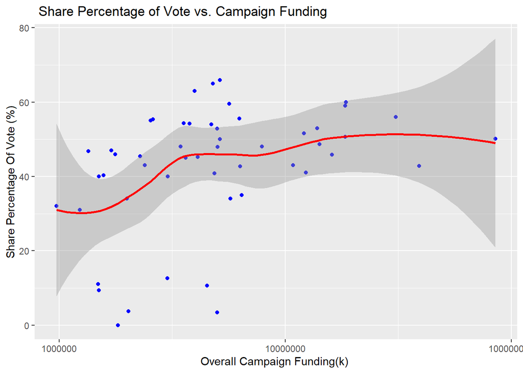

```r
#demonstrates correlation between share percentage of vote and campaign funding

cand_sp|>
  ggplot(
    mapping = aes(
      x = overallfunding,
      y = pervote))+
  geom_point(color = "blue")+
  geom_smooth(color = "red")+
  scale_x_log10()+
  labs(x = "Overall Campaign Funding(k) ",
       y = "Share Percentage Of Vote (%)",
       title = " Share Percentage of Vote vs. Campaign Funding")
```

The graph above denotes the relationship between the amount of campaign funding a candidate has and the share percentage of votes they received in the election. In this case, without evaluating which candidates won or loss, there seems to be a *slight positive correlation* between an increase in funding and an increase in the share percentage of votes the candidate received.

# **Conclusion**

From the findings above it is clear that that there is not a statistically significant relationship between campaign funds and the share percentage of votes candidates receive in elections. This can be seen in the p-value of `pervote` at 0.14 which we would fail to reject the null at the significance level of ⍺ of 0.05.

From these findings, it is obvious that my hypotheses were not fully support. Early I hypothesized that:

1. As the **amount of available campaign funding increases** so will the **wins of the candidates increase**

**Limitations**

It should be noted that this study only only considers monetary funding as the main independent variable and thus the variable that is causing the outcomes. However, in governmental elections that are a host of factors that actually effect why a candidate may or may not be able to secure the seat. There were also candidates that had to be removed from the original data set because they were included in the main data frame but may have not made it to the main election.

**Future Improvements**

In future studies more factors can be evaluated that are related to the outcome of elections. They could possibly introduce how many commercials a candidate used or polls that evaluate public opinion around how candidates do in debates. With the introduction of more factors, the causal reasoning of the study will be much stronger because there will be less confounding variables.